# Phase-locked loops

The input to a synchronous reference frame PLL (see figure) is

$V_a = 325\,\sin\,(\omega _1 \,t)\,$ + $10\,\sin\,(\omega _2\,t)\,$V,

$V_b = 325\,\sin\,(\omega _1\,t - 2\,\pi/3)\,$ + $10\,\sin\,(\omega _2\,t - 2\,\pi/3)\,$V,

$V_c = 325\,\sin\,(\omega _1\,t + 2\,\pi/3)\,$ + $10\,\sin\,(\omega _2\,t + 2\,\pi/3)\,$V,

with $f_1=50\,$Hz and $f_2=350\,$Hz. The filter transfer function is given by

$G(s) = K_p\,\displaystyle\frac{1+s\,\tau}{s\,\tau}$.

The $abc$ to $dq$ transformation is given below.

$ \begin{equation} \left[ \begin{array}{c} u_d\cr u_q\cr u_0\cr \end{array} \right] = \displaystyle\frac{2}{3} \left[ \begin{array}{cccc} \cos(\omega t) & \cos(\omega t - 2\pi /3) & \cos(\omega t + 2\pi /3) \cr -\sin(\omega t) & -\sin(\omega t - 2\pi /3) & -\sin(\omega t + 2\pi /3) \cr 1/2 & 1/2 & 1/2 \end{array} \right] \left[ \begin{array}{c} u_a\cr u_b\cr u_c\cr \end{array} \right] \end{equation} $

Plot $V_d$ and $V_q$ versus time (in the steady state) for a bandwidth of $300\,$Hz and determine the frequency components involved.

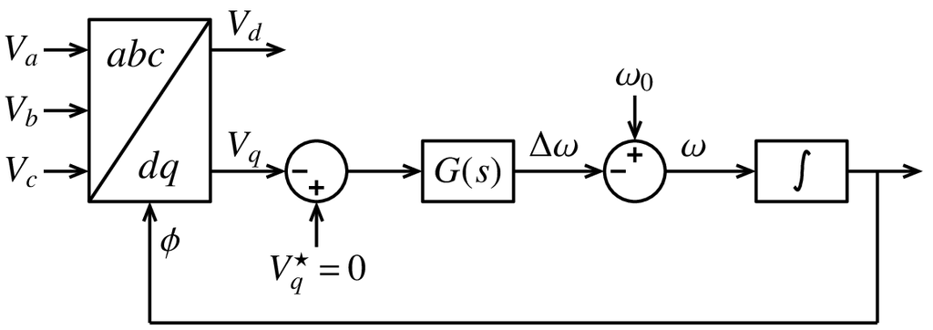

```python
from IPython.display import Image
Image(filename =r'pll_1_fig_1.png', width=450)
```

```python
# run this cell to view the circuit file.
%pycat pll_6_orig.in
```

**Execute the following cell to run GSEIM on pll_6_orig.in.**

```python
import os
import dos_unix
# uncomment for windows:
#dos_unix.d2u("pll_6_orig.in")
os.system('run_gseim pll_6_orig.in')
```

```
Circuit: filename = pll_6_orig.in
solve_ssf: ssf_iter_newton=0, rhs_ssf_norm=1.18014, ssf_period_1_compute=0.02
solve_ssf: ssf_iter_newton=1, rhs_ssf_norm=0.000261861, ssf_period_1_compute=0.02
solve_ssf: ssf_iter_newton=2, rhs_ssf_norm=6.65009e-08, ssf_period_1_compute=0.02
solve_ssf: ssf_iter_newton=3, rhs_ssf_norm=2.68631e-12, ssf_period_1_compute=0.02
solve_ssf: convergence reached.
solve_ssf: calling ssf_solve_trns for one more trns step
GSEIM: Program completed.
```

```
0
```

```
filename: pll_6.dat
average omg:   314.16
min omg:   241.75
max omg:   383.82
average vd:   325.04
min vd:   314.92
max vd:   334.93
average vq:    -0.00
min vq:    -7.10
max vq:     7.05
```

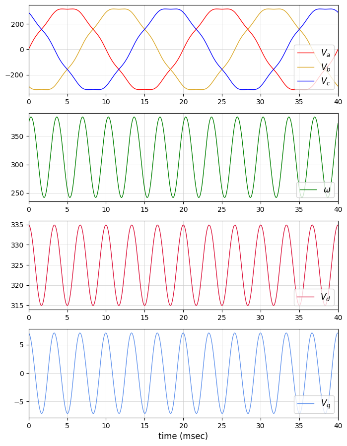

```python
import numpy as np
import matplotlib.pyplot as plt
import gseim_calc as calc
from setsize import set_size

slv = calc.slv("pll_6_orig.in")

i_slv = 0
i_out = 0
filename = slv.l_filename_all[i_slv][i_out]
print('filename:', filename)
u = np.loadtxt(filename)

t = u[:, 0]
t_end = t[-1]

va  = slv.get_array_double(i_slv, i_out, 'va', u)
vb  = slv.get_array_double(i_slv, i_out, 'vb', u)
vc  = slv.get_array_double(i_slv, i_out, 'vc', u)
vd  = slv.get_array_double(i_slv, i_out, 'vd', u)
vq  = slv.get_array_double(i_slv, i_out, 'vq', u)
omg = slv.get_array_double(i_slv, i_out, 'w',  u)

l_omg_1 = calc.min_max_1(t, omg, 0.0, t_end)
l_omg_2 = calc.avg_rms_3a(t, omg, 0.0, t_end, 1.0e-5*t_end)
print('average omg:', " %7.2f"%(l_omg_2[0]))
print('min omg:', " %7.2f"%(l_omg_1[0]))
print('max omg:', " %7.2f"%(l_omg_1[1]))

l_vd_1 = calc.min_max_1(t, vd, 0.0, t_end)
l_vd_2 = calc.avg_rms_3a(t, vd, 0.0, t_end, 1.0e-5*t_end)
print('average vd:', " %7.2f"%(l_vd_2[0]))
print('min vd:', " %7.2f"%(l_vd_1[0]))
print('max vd:', " %7.2f"%(l_vd_1[1]))

l_vq_1 = calc.min_max_1(t, vq, 0.0, t_end)
l_vq_2 = calc.avg_rms_3a(t, vq, 0.0, t_end, 1.0e-5*t_end)
print('average vq:', " %7.2f"%(l_vq_2[0]))
print('min vq:', " %7.2f"%(l_vq_1[0]))
print('max vq:', " %7.2f"%(l_vq_1[1]))

color1='red'
color2='goldenrod'
color3='blue'
color4='green'
color5='crimson'
color6='cornflowerblue'

fig, ax = plt.subplots(4, sharex=False)
plt.subplots_adjust(wspace=0, hspace=0.0)

set_size(5.5, 7, ax[0])

for i in range(4):
    ax[i].set_xlim(left=0.0, right=t_end*1e3)
    ax[i].grid(color='#CCCCCC', linestyle='solid', linewidth=0.5)

ax[0].plot(t*1e3, va, color=color1, linewidth=1.0, label="$V_a$")
ax[0].plot(t*1e3, vb, color=color2, linewidth=1.0, label="$V_b$")
ax[0].plot(t*1e3, vc, color=color3, linewidth=1.0, label="$V_c$")

ax[1].plot(t*1e3, omg, color=color4, linewidth=1.0, label="$\\omega$")
ax[2].plot(t*1e3, vd,  color=color5, linewidth=1.0, label="$V_d$")
ax[3].plot(t*1e3, vq,  color=color6, linewidth=1.0, label="$V_q$")

ax[3].set_xlabel('time (msec)', fontsize=12)

for i in range(4):
    ax[i].legend(loc = 'lower right',frameon = True, fontsize = 10, title = None,
      markerfirst = True, markerscale = 1.0, labelspacing = 0.5, columnspacing = 2.0,
      prop = {'size' : 12},)

plt.tight_layout()
plt.show()
```

This notebook was contributed by **Prof. Nakul Narayanan K**, Govt. Engineering College, Thrissur. He may be contacted at nakul@gectcr.ac.in.